# Cyclistic_project

Lucas

2022-09-29

## Summary

**Install Packages required**

```r
library(tidyverse) #data import and wrangling
library(lubridate) #date functions
library(geosphere) #package used to calculate the ride distance traveled
```

## Step 1: Collect Data

```r
Sep21 <- read_csv("tripdata_12months/202109-divvy-tripdata.csv")
Oct21 <- read_csv("tripdata_12months/202110-divvy-tripdata.csv")
Nov21 <- read_csv("tripdata_12months/202111-divvy-tripdata.csv")
Dec21 <- read_csv("tripdata_12months/202112-divvy-tripdata.csv")
Jan22 <- read_csv("tripdata_12months/202201-divvy-tripdata.csv")
Feb22 <- read_csv("tripdata_12months/202202-divvy-tripdata.csv")
Mar22 <- read_csv("tripdata_12months/202203-divvy-tripdata.csv")
Apr22 <- read_csv("tripdata_12months/202204-divvy-tripdata.csv")
May22 <- read_csv("tripdata_12months/202205-divvy-tripdata.csv")
Jun22 <- read_csv("tripdata_12months/202206-divvy-tripdata.csv")
Jul22 <- read_csv("tripdata_12months/202207-divvy-tripdata.csv")
Aug22 <- read_csv("tripdata_12months/202208-divvy-tripdata.csv")
```

## Step 2: Wrangle data and combine into a single file

- Comparing column names each of the files

```r
colnames(Sep21)
```

```
##  [1] "ride_id"            "rideable_type"      "started_at"
##  [4] "ended_at"           "start_station_name" "start_station_id"
##  [7] "end_station_name"   "end_station_id"     "start_lat"
## [10] "start_lng"          "end_lat"            "end_lng"
## [13] "member_casual"
```

```r
colnames(Oct21)
```

```
##  [1] "ride_id"            "rideable_type"      "started_at"
##  [4] "ended_at"           "start_station_name" "start_station_id"
##  [7] "end_station_name"   "end_station_id"     "start_lat"
## [10] "start_lng"          "end_lat"            "end_lng"
## [13] "member_casual"
```

```r
colnames(Nov21)
```

```
##  [1] "ride_id"            "rideable_type"      "started_at"
##  [4] "ended_at"           "start_station_name" "start_station_id"
##  [7] "end_station_name"   "end_station_id"     "start_lat"
## [10] "start_lng"          "end_lat"            "end_lng"
## [13] "member_casual"
```

```r
colnames(Dec21)
```

```
##  [1] "ride_id"            "rideable_type"      "started_at"
##  [4] "ended_at"           "start_station_name" "start_station_id"
##  [7] "end_station_name"   "end_station_id"     "start_lat"
## [10] "start_lng"          "end_lat"            "end_lng"
## [13] "member_casual"
```

```r
colnames(Jan22)
```

```
##  [1] "ride_id"            "rideable_type"      "started_at"
##  [4] "ended_at"           "start_station_name" "start_station_id"
##  [7] "end_station_name"   "end_station_id"     "start_lat"
## [10] "start_lng"          "end_lat"            "end_lng"
## [13] "member_casual"
```

```r
colnames(Feb22)
```

```
##  [1] "ride_id"            "rideable_type"      "started_at"
##  [4] "ended_at"           "start_station_name" "start_station_id"
##  [7] "end_station_name"   "end_station_id"     "start_lat"
## [10] "start_lng"          "end_lat"            "end_lng"
## [13] "member_casual"
```

```r
colnames(Apr22)
```

```
##  [1] "ride_id"            "rideable_type"      "started_at"
##  [4] "ended_at"           "start_station_name" "start_station_id"
##  [7] "end_station_name"   "end_station_id"     "start_lat"
## [10] "start_lng"          "end_lat"            "end_lng"
## [13] "member_casual"
```

```r
colnames(May22)
```

```
##  [1] "ride_id"            "rideable_type"      "started_at"
##  [4] "ended_at"           "start_station_name" "start_station_id"
##  [7] "end_station_name"   "end_station_id"     "start_lat"
## [10] "start_lng"          "end_lat"            "end_lng"
## [13] "member_casual"
```

```r
colnames(Jun22)
```

```
##  [1] "ride_id"            "rideable_type"      "started_at"
##  [4] "ended_at"           "start_station_name" "start_station_id"
##  [7] "end_station_name"   "end_station_id"     "start_lat"
## [10] "start_lng"          "end_lat"            "end_lng"
## [13] "member_casual"
```

```r
colnames(Jul22)
```

```
##  [1] "ride_id"            "rideable_type"      "started_at"
##  [4] "ended_at"           "start_station_name" "start_station_id"
##  [7] "end_station_name"   "end_station_id"     "start_lat"
## [10] "start_lng"          "end_lat"            "end_lng"
## [13] "member_casual"
```

```r
colnames(Aug22)
```

```
##  [1] "ride_id"            "rideable_type"      "started_at"
##  [4] "ended_at"           "start_station_name" "start_station_id"
##  [7] "end_station_name"   "end_station_id"     "start_lat"
## [10] "start_lng"          "end_lat"            "end_lng"
## [13] "member_casual"
```

**Inspecting data frame**

```r
str(Sep21)
str(Oct21)
str(Nov21)
str(Dec21)
str(Jan22)
str(Feb22)
str(Apr22)
str(May22)
str(Jun22)
str(Jul22)
str(Aug22)
```

**Gathering all data frames in one Big data frame**

```r
all_trips <- bind_rows(Sep21,Oct21,Nov21,Dec21,Jan22,Feb22,Apr22,May22,Jun22,Jul22,Aug22)
```

## Step 3: Prepare dataset

**Checking distinct values in “member_casual” column**

```r
table(all_trips$member_casual)
```

```
##
##  casual  member
## 2378597 3220404
```

**Inspecting Data Frame**

```r
str(all_trips)
```

```
## spec_tbl_df [5,599,001 × 13] (S3: spec_tbl_df/tbl_df/tbl/data.frame)
##  $ ride_id           : chr [1:5599001] "9DC7B962304CBFD8" "F930E2C6872D6B32" "6EF72137900BB910" "78D1DE133B3DBF55" ...
##  $ rideable_type     : chr [1:5599001] "electric_bike" "electric_bike" "electric_bike" "electric_bike" ...
##  $ started_at        : POSIXct[1:5599001], format: "2021-09-28 16:07:10" "2021-09-28 14:24:51" ...
##  $ ended_at          : POSIXct[1:5599001], format: "2021-09-28 16:09:54" "2021-09-28 14:40:05" ...
##  $ start_station_name: chr [1:5599001] NA NA NA NA ...
##  $ start_station_id  : chr [1:5599001] NA NA NA NA ...
##  $ end_station_name  : chr [1:5599001] NA NA NA NA ...
##  $ end_station_id    : chr [1:5599001] NA NA NA NA ...
##  $ start_lat         : num [1:5599001] 41.9 41.9 41.8 41.8 41.9 ...
##  $ start_lng         : num [1:5599001] -87.7 -87.6 -87.7 -87.7 -87.7 ...
##  $ end_lat           : num [1:5599001] 41.9 42 41.8 41.8 41.9 ...
##  $ end_lng           : num [1:5599001] -87.7 -87.7 -87.7 -87.7 -87.7 ...
##  $ member_casual     : chr [1:5599001] "casual" "casual" "casual" "casual" ...
##  - attr(*, "spec")=
##   .. cols(
##   ..   ride_id = col_character(),
##   ..   rideable_type = col_character(),
##   ..   started_at = col_datetime(format = ""),
##   ..   ended_at = col_datetime(format = ""),
##   ..   start_station_name = col_character(),
##   ..   start_station_id = col_character(),
##   ..   end_station_name = col_character(),
##   ..   end_station_id = col_character(),
##   ..   start_lat = col_double(),
##   ..   start_lng = col_double(),
##   ..   end_lat = col_double(),
##   ..   end_lng = col_double(),
##   ..   member_casual = col_character()
##   .. )
##  - attr(*, "problems")=<externalptr>
```

**Add “ride_length” Calculation (in seconds)**

```r
all_trips$ride_length <- difftime(all_trips$ended_at,all_trips$started_at, units = "secs")
```

**Converting “ride_length” to numeric**

```r
all_trips$ride_length <- as.numeric(as.character(all_trips$ride_length))
```

**Add columns for date, year, month, day of the week and day**

```r
all_trips$date <- as.Date(all_trips$started_at) # format yyyy-mm-dd
all_trips$year <- format(as.Date(all_trips$date),"%Y")
all_trips$month <- format(as.Date(all_trips$date),"%m")
all_trips$day_of_week <- format(as.Date(all_trips$date),"%A")
all_trips$day <- format(as.Date(all_trips$date),"%d")
```

```r
all_trips %>%
  filter(ride_length < 0) %>%
  summarize(duration_less_zero = n())
```

```
## # A tibble: 1 × 1
##   duration_less_zero
##                <int>
## 1                133
```

## Step 4: Clean dataset

### Dropping “bad” data

**4.1- Removing rows with “ride_length” less than zero**

```r
all_trips_cleaned <- all_trips[!(all_trips$ride_length <= 0),]
```

**4.2- There are rows with no recorded station names**

```r
sum(is.na(all_trips_cleaned$start_station_name) | is.na(all_trips_cleaned$end_station_name))
```

```
## [1] 1254529
```

These incomplete rows should be removed

```r
all_trips_cleaned <- all_trips_cleaned[!(is.na(all_trips_cleaned$start_station_name) | is.na(all_trips_cleaned$end_station_name)),]
```

**4.3- Removing Duplicated Rows**

```r
all_trips_cleaned <- all_trips_cleaned[!duplicated(all_trips_cleaned$ride_id),]
```

## Step 5: Data processing

**Creating a new columns “ride_length_min”**

```r
all_trips_cleaned$ride_length_min <- all_trips_cleaned$ride_length / 60
all_trips_cleaned$ride_length_min <- round(all_trips_cleaned$ride_length_min, 2)
```

**Calculating the ride distance traveled in meters using “geosphere” package**

```r
all_trips_cleaned$ride_distance <- distGeo(matrix(c(all_trips_cleaned$start_lng, all_trips_cleaned$start_lat), ncol=2), matrix(c(all_trips_cleaned$end_lng, all_trips_cleaned$end_lat), ncol=2))
```

## Step 6: Data Analysis

**6.1- Analysing rides and distance**

```r
summary(all_trips_cleaned$ride_length_min) # ride duration in minutes
```

```
##     Min.  1st Qu.   Median     Mean  3rd Qu.     Max.
##     0.02     6.33    11.07    18.05    19.83 40705.02
```

```r
all_trips_cleaned$ride_distance_km <- round(all_trips_cleaned$ride_distance / 1000, 2)
summary(all_trips_cleaned$ride_distance_km) # distance in Kilometers
```

```
##     Min.  1st Qu.   Median     Mean  3rd Qu.     Max.
##    0.000    0.890    1.590    2.111    2.770 1192.250
```

**6.2- Comparing number of trips, duration and distance by members and casual**

**6.2.1- Avg and max ride time and ride distance**

```r
ride_summary <- all_trips_cleaned %>%
  group_by(member_casual) %>%
  summarize(number_of_rides = n(),avg_duration_min = round(mean(ride_length_min),2), max_duration_min = max(ride_length_min), avg_dist_km = round(mean(ride_distance_km),2), max_dist_km = max(ride_distance_km))

ride_summary
```

```
## # A tibble: 2 × 6
##   member_casual number_of_rides avg_duration_min max_duration_…¹ avg_d…² max_d…³
##   <chr>                   <int>            <dbl>           <dbl>   <dbl>   <dbl>
## 1 casual                1810714             25.7          40705.    2.19  1192.
## 2 member                2533170             12.6           1493.    2.06    27.5
## # … with abbreviated variable names ¹max_duration_min, ²avg_dist_km,
## #   ³max_dist_km
```

**6.2.2- Average ride time and ride distance by day of the week**

```r
# translating days of the week to english
all_trips_cleaned <- all_trips_cleaned %>%
  mutate(day_of_week = recode(day_of_week, "domingo"="sunday", "segunda-feira"="monday", "terça-feira"="tuesday","quarta-feira"="wednesday","quinta-feira"="thursday","sexta-feira"="friday","sábado"="saturday"))

# Ordering the days of the week in correctly
all_trips_cleaned$day_of_week <- ordered(all_trips_cleaned$day_of_week, levels=c("sunday", "monday", "tuesday", "wednesday", "thursday", "friday", "saturday"))

analyse_wday <- all_trips_cleaned %>%
  group_by(member_casual,day_of_week) %>%
  summarize(number_of_rides = n(), avg_duration_min = round(mean(ride_length_min),2), avg_dist_km = round(mean(ride_distance_km),2)) %>%
  arrange(day_of_week,member_casual)
analyse_wday
```

```
## # A tibble: 14 × 5
## # Groups:   member_casual [2]
##    member_casual day_of_week number_of_rides avg_duration_min avg_dist_km
##    <chr>         <ord>                 <int>            <dbl>       <dbl>
##  1 casual        sunday               331018             29.6        2.26
##  2 member        sunday               297233             14.2        2.13
##  3 casual        monday               210191             26.6        2.1
##  4 member        monday               353800             12.1        2.02
##  5 casual        tuesday              198369             22.6        2.11
##  6 member        tuesday              400266             11.9        2.03
##  7 casual        wednesday            206060             21.8        2.11
##  8 member        wednesday            406479             11.9        2.04
##  9 casual        thursday             222445             22.8        2.15
## 10 member        thursday             388369             12.1        2.05
## 11 casual        friday               253021             24.1        2.15
## 12 member        friday               350394             12.3        2.02
## 13 casual        saturday             389610             28.2        2.3
## 14 member        saturday             336629             14.1        2.15
```

**6.3- Data Visualization**

**6.3.1- Analysing riders type by weekday**

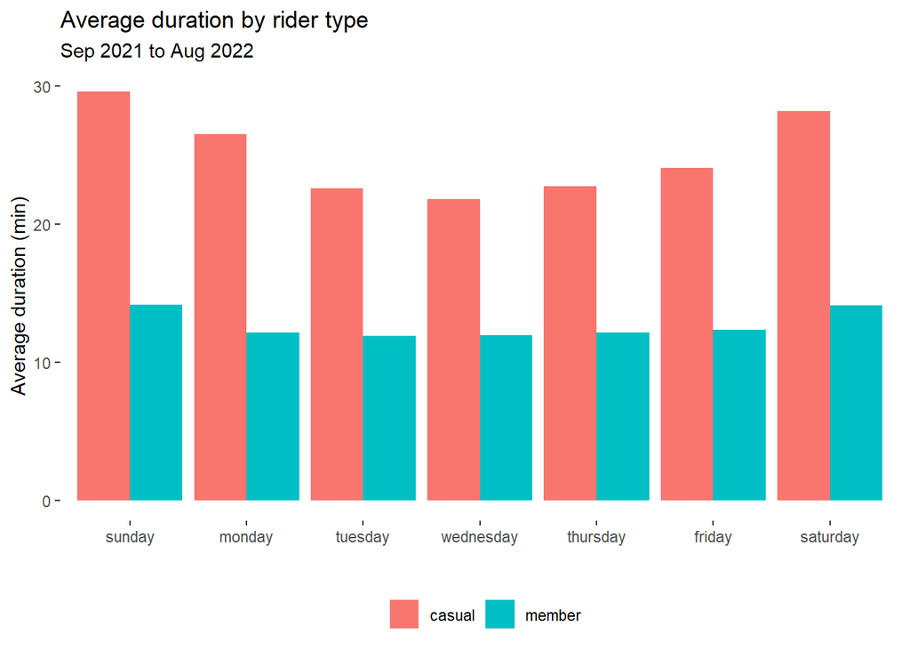

```r
analyse_wday %>%
  ggplot(aes(x=day_of_week,y=avg_duration_min, fill=member_casual)) +
  geom_col(position = "dodge")+
  labs(title = "Average duration by rider type", subtitle = "Sep 2021 to Aug 2022", x="", y="Average duration (min)", fill= "")+
  theme(legend.position = "bottom",panel.background = element_rect(fill="white"))
```

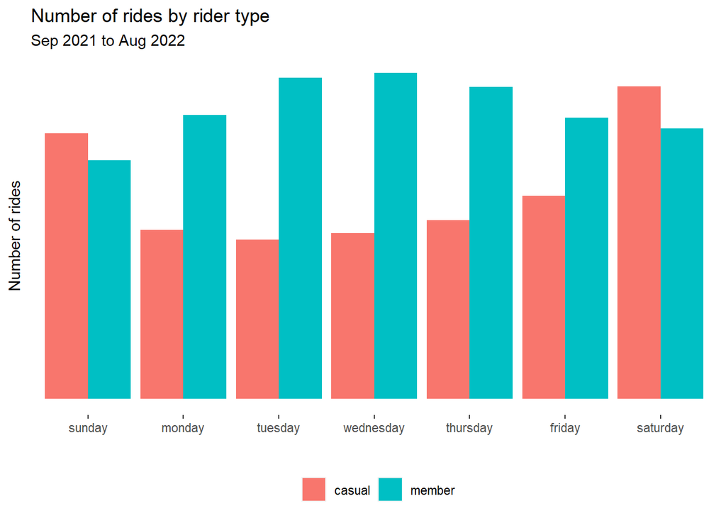

```r
analyse_wday %>%
  ggplot(aes(x=day_of_week,y=number_of_rides, fill=member_casual)) +
  geom_col(position="dodge") +
  labs(title = "Number of rides by rider type", subtitle = "Sep 2021 to Aug 2022", x="", y="Number of rides", fill= "")+
  theme(legend.position = "bottom", axis.text.y = element_blank(), axis.ticks.y = element_blank(),panel.background = element_rect(fill="white"))
```

**Bike types that members and casual are using**

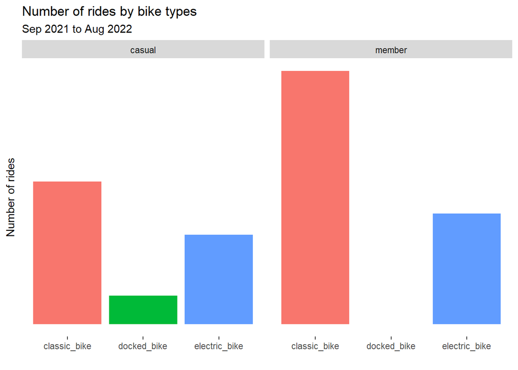

```r
all_trips_cleaned %>%
  ggplot(aes(x=rideable_type, fill=rideable_type)) +
  geom_bar()+
  facet_wrap(~ member_casual)+
  labs(title = "Number of rides by bike types", subtitle = "Sep 2021 to Aug 2022", x="", y="Number of rides")+
  theme(legend.position = "none", axis.text.y = element_blank(), axis.ticks.y = element_blank(),panel.background = element_rect(fill="white"))
```

**6.3.2- Analysing stations**

- Preparing data frames

```r
# filter stations
stations <- all_trips_cleaned %>%
  select(start_station_name,member_casual,start_lat,start_lng)

# Create two data frames by riders type
casual_st <- stations[stations$member_casual == "casual",]
member_st <- stations[stations$member_casual == "member",]

# Creating two data frames by riders type which include number of trips, latitude and longitude coordinates for each station
map_casual <- casual_st %>%
  select(start_station_name,start_lat,start_lng) %>%
  group_by(start_station_name) %>%
  mutate(num_trips = n()) %>%
  distinct(start_station_name, .keep_all = TRUE) # There are more than on start_lat and start_lng by stations. ".keep_all" keep the first row

map_member <- member_st %>%
  select(start_station_name,start_lat,start_lng) %>%
  group_by(start_station_name) %>%
  mutate(num_trips = n()) %>%
  distinct(start_station_name, .keep_all = TRUE) # keeping the first row of start_lat, start_lng because they are not distinct by station name
```

**CASUAL**

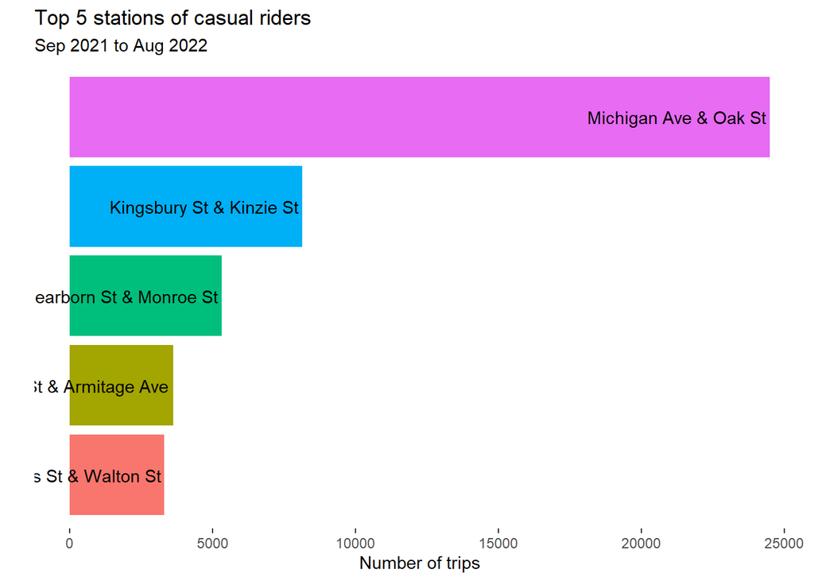

```r
map_casual_5 <- map_casual[1:5,] %>% arrange(-num_trips)
map_casual_5$start_station_name <- factor(map_casual_5$start_station_name, levels = map_casual_5$start_station_name[order(map_casual_5$num_trips, decreasing = FALSE)])

map_casual_5 %>%
  ggplot(aes(x = start_station_name, y = num_trips, fill=start_station_name))+
  geom_col()+
  coord_flip()+
  geom_text(aes(label=start_station_name), hjust=1.02, color="black")+
  theme(legend.position = "none",axis.text.y = element_blank(), axis.ticks.y = element_blank(), panel.background = element_rect(fill="white"))+
  labs(x = "", y = "Number of trips", title = "Top 5 stations of casual riders", subtitle = "Sep 2021 to Aug 2022")
```

**MEMBER**

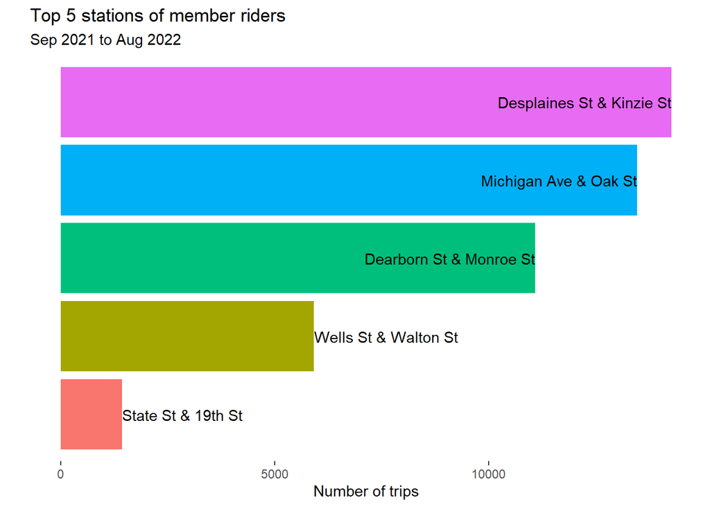

```r
map_member_5 <- map_member[1:5,] %>% arrange(-num_trips)
map_member_5$start_station_name <- factor(map_member_5$start_station_name, levels = map_member_5$start_station_name[order(map_member_5$num_trips, decreasing = FALSE)])

map_member_5 %>%
  ggplot(aes(x = start_station_name, y = num_trips, fill=start_station_name))+
  geom_col()+
  coord_flip()+
  geom_text(aes(label=start_station_name), hjust = "inward", color="black")+
  theme(legend.position = "none",axis.text.y = element_blank(), axis.ticks.y = element_blank(), panel.background = element_rect(fill="white"))+
  labs(x = "", y = "Number of trips", title = "Top 5 stations of member riders", subtitle = "Sep 2021 to Aug 2022")
```

**Interactive leaflet to show the most popular stations**

- Installing package to interactive format “leaflet”

```r
library(leaflet)
```

**CASUAL**

```r
mybins_casual <- seq(0, 56000, by = 7000)

mypalette_casual <- colorBin(palette ="plasma",domain = map_casual$num_trips, na.color = "transparent", bins = mybins_casual)

mytext <- paste(map_casual$start_station_name, " || ",
  "Number of trips: ", map_casual$num_trips, sep = "")

vizmap_casual <- leaflet(map_casual) %>%
  addTiles() %>%
  setView(lng = -87.6298, lat=41.8781, zoom = 13) %>%
  addProviderTiles(providers$CartoDB.Positron) %>%
  addCircleMarkers(lng = ~ start_lng, lat = ~ start_lat, fillColor = ~ mypalette_casual(num_trips),
                   fillOpacity = 0.7, radius = 8, stroke = FALSE,label = mytext,
                   labelOptions = labelOptions(style = list("font-weight" = "normal", padding = "3px 8px"), textsize = "13px", direction = "auto")) %>%
  addLegend(
    pal = mypalette_casual,
    values = ~ num_trips,
    opacity = 0.9,
    title = "# Casual Trips",
    position = "bottomright"
    )

vizmap_casual
```

[interactive chart not shown]

**MEMBERS**

```r
mybins_member <- seq(0, 25000, by = 5000)

mypalette_member <- colorBin(palette ="plasma",domain = map_member$num_trips, na.color = "transparent", bins = mybins_member)

mytext <- paste(map_member$start_station_name, " || ",
  "Number of trips: ", map_member$num_trips, sep = "")

vizmap_member <- leaflet(map_member) %>%
  addTiles() %>%
  setView(lng = -87.6298, lat=41.8781, zoom = 13) %>%
  addProviderTiles(providers$CartoDB.Positron) %>%
  addCircleMarkers(lng = ~ start_lng, lat = ~ start_lat, fillColor = ~ mypalette_member(num_trips),
                   fillOpacity = 0.7, radius = 8, stroke = FALSE,label = mytext,
                   labelOptions = labelOptions(style = list("font-weight" = "normal", padding = "3px 8px"), textsize = "13px", direction = "auto")) %>%
  addLegend(
    pal = mypalette_member,
    values = ~ num_trips,
    opacity = 0.9,
    title = "# Member Trips",
    position = "bottomright"
    )

vizmap_member
```

[interactive chart not shown]

**6.3.3- Visualize trends by month**

```r
df_month <- all_trips_cleaned %>%
  select(ride_id,rideable_type,start_station_name,end_station_name,member_casual,ride_distance_km,ride_length_min,date,month,year,day_of_week,day)
```